# Part 2 - Simple Linear Regression

#### Introduction

Linear regression assumes a linear or straight line relationship between the input variables (X) and the single output variable (y).

More specifically, that output (y) can be calculated from a linear combination of the input variables (X). When there is a single input variable, the method is referred to as a simple linear regression.

The line for a simple linear regression model can be written as:

y = b0 + b1 * x

where b0 and b1 are the coefficients we must estimate from the training data.

We can estimate the coefficients as follows:

B1 = sum((x(i) - mean(x)) (y(i) - mean(y))) / sum( (x(i) - mean(x))^2 )  
B0 = mean(y) - B1 mean(x)

where the i refers to the value of the ith value of the input x or output y.

#### Getting started

```
1. Calculate Mean, Sum Of Squared Differences and Covariance.
2. Estimate the coefficients.
3. Put it all together.
4. Make Predictions.
```

#### 1. Calculate Mean, Sum Of Squared Differences and Covariance.

```python
# Calculate the mean value of a list of numbers
def mean(values):
	return sum(values) / float(len(values))
```

```python
# Calculate the variance of a list of numbers
def sum_of_squared_diff(values, mean):
	return sum([(x-mean)**2 for x in values])
```

```python
# Calculate covariance between x and y
def covariance(x, mean_x, y, mean_y):
	covar = 0.0
	for i in range(len(x)):
		covar += (x[i] - mean_x) * (y[i] - mean_y)
	return covar
```

#### 2. Estimate the coefficients.

Lest repeat how you can estimate the coeffecients:

B1 = sum((x(i) - mean(x)) (y(i) - mean(y))) / sum( (x(i) - mean(x))^2 )  
B0 = mean(y) - B1 mean(x)

```python
# Calculate coefficients
def coefficients(dataset):
	x = [row[0] for row in dataset]
	y = [row[1] for row in dataset]
	x_mean, y_mean = mean(x), mean(y)
	b1 = covariance(x, x_mean, y, y_mean) / sum_of_squared_diff(x, x_mean)
	b0 = y_mean - b1 * x_mean
	return [b0, b1]
```

#### 3. Put it all together.

Let’s pull together everything we have learned and make a method for traning and testing a dataset.

The equation to make predictions with a simple linear regression model is as follows:

y = b0 + b1 * x

Below is a function we have named simple_linear_regression() that implements the prediction equation to make predictions on a test dataset. It also ties together the estimation of the coefficients on training data from the steps above.

The coefficients prepared from the training data are used to make predictions on the test data, which are then returned.

```python
# Simple linear regression algorithm
def simple_linear_regression(train, test):
	predictions = list()
	b0, b1 = coefficients(train)
	for row in test:
		yhat = b0 + b1 * row[0]
		predictions.append(yhat)
	return predictions
```

All together it looks like this:

```python
# Calculate the mean value of a list of numbers
def mean(values):
	return sum(values) / float(len(values))


# Calculate the variance of a list of numbers
def sum_of_squared_diff(values, mean):
	return sum([(x-mean)**2 for x in values])


# Calculate covariance between x and y
def covariance(x, mean_x, y, mean_y):
	covar = 0.0
	for i in range(len(x)):
		covar += (x[i] - mean_x) * (y[i] - mean_y)
	return covar


# Calculate coefficients
def coefficients(dataset):
	x = [row[0] for row in dataset]
	y = [row[1] for row in dataset]
	x_mean, y_mean = mean(x), mean(y)
	b1 = covariance(x, x_mean, y, y_mean) / sum_of_squared_diff(x, x_mean)
	b0 = y_mean - b1 * x_mean
	return [b0, b1]


# Simple linear regression algorithm
def simple_linear_regression(train, test):
	predictions = list()
	b0, b1 = coefficients(train)
	for row in test:
		yhat = b0 + b1 * row[0]
		predictions.append(yhat)
	return predictions
```

#### 4. Make Predictions.

Now, let's test our simple linear regression on a small dataset. The dataset we will use is just hardcoded dummy data. But we can easily imagine real data would look very familiar. In fact you should try to find a small real world datset and try out your regression algorithm.

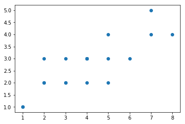

```python
import matplotlib.pyplot as plt
x = [1,2,4,3,5,6,2,4,7,4,5,4,3,7,8,5,1,2,4,3]
y = [1,2,2,2,4,3,3,3,4,3,2,3,3,5,4,3,1,2,3,2]
plt.scatter(x,y)
plt.show()
```

Split dataset into train and test:

```python
trainX, testX = x[0:12], x[12:len(x)-1]
trainY, testY = y[0:12], y[12:len(x)-1]
```

```python
train = []
test = []
for i in range(len(trainX)):
    train.append([trainX[i], trainY[i]])

for i in range(len(testX)):
    test.append([testX[i], testY[i]])
```

```python
predictions = simple_linear_regression(train, test)
predictions
```

```
[2.3417721518987342,
 3.7594936708860764,
 4.113924050632912,
 3.0506329113924053,
 1.6329113924050627,
 1.9873417721518982,
 2.6962025316455698]
```

These are the results of the test dataset. They represent the `y` value in y = b0 + b1 * x

Let's plot it into a graph to see how we did.

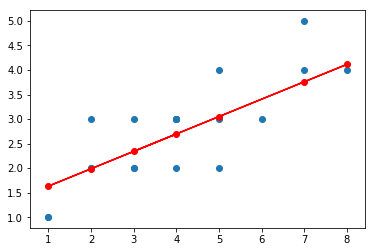

```python
plt.scatter(x,y)
plt.scatter(testX,predictions, c=("red"))
plt.plot(testX, predictions, c=("red"))
plt.show()
```